# TD 3 — Analyse descriptive des débarquements d’une espèce en Manche Est

Introduction à l’halieutique — M2 Sciences de la Mer

Auteur·rice

Laurent Dubroca

Date de publication

24 novembre 2026

# Objectifs et consignes

Ce TD prolonge le cours « La pêche, une activité humaine ». À partir des statistiques de débarquements des navires français en **Manche Est** (division CIEM 7d), vous réaliserez une **analyse descriptive des débarquements d’une espèce** de votre choix, **dans le temps et dans l’espace** :

1. découvrir et comprendre les jeux de données ;
2. choisir une espèce ;
3. décrire l’évolution des débarquements annuels ;
4. comparer les engins de pêche ;
5. cartographier les débarquements par rectangle statistique, année par année ;
6. calculer et interpréter une capture par unité d’effort.

**Durée** : environ 2 heures.

**Rendu** : ce document complété (le `.qmd` **et** le `.html` compilé), à envoyer par mail à l’intervenant **à la fin de la demi-journée**. Il est noté. On attend un code qui fonctionne, des figures lisibles et, surtout, des **commentaires rédigés** de vos résultats.

**Mode d’emploi**

1. Travaillez dans le projet RStudio créé au TD précédent.
2. Copiez-y ce fichier et le dossier `data/` qui l’accompagne (fichiers `landings.csv`, `landings_rect.csv`, `icesrect.rds`, `icesdiv.rds`, `cote.rds`, `REFERENTIEL_ENGINS.txt`, `REFERENTIEL_ESPECES.txt`).
3. Exécutez les blocs d’exemple, puis complétez les blocs **« À vous »** et rédigez vos commentaires à la place de *(commentez ici)*.
4. À partir de la partie « Choisir une espèce », un **exemple corrigé** sur la dorade grise (`BRB`) est donné dans des encadrés repliés. Ses objets portent le suffixe `_ex` (`sp_ex`, `annuel_ex`…) pour ne pas écraser les vôtres. Inspirez-vous-en, mais travaillez sur **une autre espèce** et rédigez vos propres commentaires. La partie « Découvrir les données » et la synthèse n’ont pas de corrigé.

**NotePackages nécessaires**

**ggplot2** pour les graphiques et **sf** pour les cartes. Le bloc suivant les installe s’ils manquent, puis les charge.

```r
for (p in c("ggplot2", "sf")) {
    if (!requireNamespace(p, quietly = TRUE)) install.packages(p)
}
library(ggplot2)
library(sf)
```

# 1 Découvrir les données

## 1.1 D’où viennent ces données ?

Les débarquements des navires de pêche français sont déclarés par les pêcheurs (journaux de bord, fiches de pêche) et enregistrés lors des ventes en criée. Le **Système d’Informations Halieutiques** (SIH) de l’Ifremer croise ces sources pour reconstituer, navire par navire et marée par marée, les captures et l’effort de pêche (données dites « Sacrois »). Les fichiers de ce TD en sont des **agrégats** pour la Manche Est, depuis 2000.

**ImportantSecret statistique**

Pour protéger les données individuelles des entreprises de pêche, une ligne n’est diffusée que si elle concerne **au moins 5 navires**. Les lignes plus rares ont été supprimées : les totaux sont donc des **minimums**, et le fichier par rectangle (plus détaillé) perd davantage de lignes que le fichier global.

## 1.2 Lire les fichiers

Les chemins sont relatifs au dossier du document : les fichiers doivent se trouver dans un sous-dossier `data/`.

```r
# Débarquements par année, espèce et engin
lan <- read.csv("data/landings.csv")
# Débarquements par année, espèce, rectangle statistique et engin
lan_rect <- read.csv("data/landings_rect.csv")
# Référentiels : fichiers texte séparés par des tabulations, encodés en ISO-8859-1
ref_engin <- read.delim("data/REFERENTIEL_ENGINS.txt", fileEncoding = "ISO-8859-1")
ref_espece <- read.delim("data/REFERENTIEL_ESPECES.txt", fileEncoding = "ISO-8859-1")
# Couches cartographiques (objets sf) : rectangles, division CIEM et terres
rect <- readRDS("data/icesrect.rds")
div <- readRDS("data/icesdiv.rds")
cote <- readRDS("data/cote.rds") # trait de côte (Natural Earth, 1:10 M)
```

## 1.3 Appréhender les objets

Avant toute analyse, on regarde **ce que contient chaque objet**. Voici les commandes utiles ; exécutez-les et lisez attentivement leurs sorties.

```r
str(lan) # type et premières valeurs de chaque colonne
```

```
'data.frame':   14367 obs. of  7 variables:
 $ year       : int  2000 2000 2000 2000 2000 2000 2000 2000 2000 2000 ...
 $ faocode    : chr  "BIB" "BIB" "BIB" "BIB" ...
 $ gear       : chr  "" "DRB" "FPO" "GEN" ...
 $ totalweight: num  7446 11726 518 385 22084 ...
 $ totaleuros : num  5460 6642 336 229 12285 ...
 $ nnav       : int  5 80 11 5 71 114 14 550 36 11 ...
 $ nbtrip     : int  91 242 29 5 616 1435 223 7636 475 133 ...
```

```r
head(lan) # premières lignes
```

```
  year faocode gear totalweight totaleuros nnav nbtrip
1 2000     BIB          7446.00    5459.53    5     91
2 2000     BIB  DRB    11725.51    6641.88   80    242
3 2000     BIB  FPO      517.89     336.32   11     29
4 2000     BIB  GEN      385.00     229.40    5      5
5 2000     BIB  GNS    22084.36   12285.04   71    616
6 2000     BIB  GTR    84980.00   49393.62  114   1435
```

```r
summary(lan) # résumé : min, max, moyenne, valeurs manquantes (NA)
```

```
      year           faocode             gear        totalweight
 Min.   :2000   Length   :14367   Length   :14367   Min.   :0.000e+00
 1st Qu.:2007   N.unique :  201   N.unique :   27   1st Qu.:4.429e+02
 Median :2013   N.blank  :    0   N.blank  :  218   Median :2.438e+03
 Mean   :2013   Min.nchar:    3   Min.nchar:    0   Mean   :1.321e+05
 3rd Qu.:2019   Max.nchar:    3   Max.nchar:    3   3rd Qu.:1.657e+04
 Max.   :2026                                       Max.   :3.036e+07

   totaleuros             nnav             nbtrip
 Min.   :2.000e-01   Min.   :   5.00   Min.   :    5
 1st Qu.:4.702e+02   1st Qu.:   9.00   1st Qu.:   27
 Median :2.311e+03   Median :  22.00   Median :   91
 Mean   :8.728e+04   Mean   :  80.51   Mean   :  741
 3rd Qu.:1.297e+04   3rd Qu.:  65.00   3rd Qu.:  364
 Max.   :2.130e+07   Max.   :1459.00   Max.   :28888
 NAs    :9627
```

```r
range(lan$year) # période couverte
```

```
[1] 2000 2026
```

```r
length(unique(lan$faocode)) # nombre d'espèces
```

```
[1] 201
```

```r
table(lan$gear) # nombre de lignes par engin
```

```
      DHB  DRB  FPO  FYK  GEN  GES  GND  GNS  GTN  GTR  LHM  LHP   LL  LLS  LTL
 218    4 1458  962    2   96   27  106 1014   21 1573    2  196    8  472  226
 MHI  OTB  OTM  OTT   PS  PTB  PTM  SDN  SPR  SSC  TBB
   5 2410 1455  631  197  248 1022  794   19  109 1092
```

Variables des fichiers de débarquements

| Variable | Signification | Unité |
| --- | --- | --- |
| `year` | année de débarquement |  |
| `faocode` | code FAO à 3 lettres de l’espèce |  |
| `icesrect` | rectangle statistique CIEM (fichier `landings_rect.csv` uniquement) |  |
| `gear` | code de l’engin de pêche (classification FAO) |  |
| `totalweight` | poids débarqué | kg |
| `totaleuros` | valeur des ventes | € |
| `nnav` | nombre de navires concernés | navires |
| `nbtrip` | nombre de marées (sorties en mer) concernées | marées |

```r
str(lan_rect)
```

```
'data.frame':   46875 obs. of  8 variables:
 $ year       : int  2000 2000 2000 2000 2000 2000 2000 2000 2000 2000 ...
 $ faocode    : chr  "BIB" "BIB" "BIB" "BIB" ...
 $ icesrect   : chr  "" "" "" "" ...
 $ gear       : chr  "" "GNS" "GTR" "OTB" ...
 $ totalweight: num  7446 848 4728 90029 4054 ...
 $ totaleuros : num  5460 466 2331 55084 2592 ...
 $ nnav       : int  5 6 19 15 15 19 7 12 59 6 ...
 $ nbtrip     : int  91 41 116 199 133 68 43 217 879 15 ...
```

```r
sort(unique(lan_rect$icesrect)) # rectangles statistiques présents
```

```
 [1] ""     "27E8" "27E9" "27F0" "28E8" "28E9" "28F0" "28F1" "29E8" "29E9"
[11] "29F0" "29F1" "30E8" "30E9" "30F0" "30F1" "30F2"
```

```r
head(ref_engin) # correspondance code -> nom de l'engin
```

```
  ENGIN_COD                                            ENGIN_LIB
1        PS Filets tournants avec coulisse (sennes coulissantes)
2       PS1           Sennes (à poche) manoeuvrées par un bateau
3       PS2        Sennes (à poche) manoeuvrées par deux bateaux
4        LA       Filets tournants sans coulisse (filet lamparo)
5        SB                                      Sennes de plage
6        SV                                 Sennes halées à bord
```

```r
head(ref_espece) # correspondance code FAO -> nom de l'espèce
```

```
  ESP_COD_FAO  ESP_LIB_FAO_FRANCAIS
1         DHB   Pateobatis bleekeri
2         DHC   Urogymnus polylepis
3         DHF            Raie fouet
4         DHG  Maculabatis gerrardi
5         DHR  Himantura granulatus
6         DHM Brevitrygon imbricata
```

Les objets cartographiques sont des tableaux de classe **`sf`** (*simple features*) : une colonne `geometry` contient les polygones.

```r
class(rect)
```

```
[1] "sf"         "data.frame"
```

```r
rect # 15 rectangles statistiques de la division 7d
```

```
Simple feature collection with 15 features and 1 field
Geometry type: POLYGON
Dimension:     XY
Bounding box:  xmin: -2 ymin: 49 xmax: 3 ymax: 51
Geodetic CRS:  WGS 84
First 10 features:
     offname                       geometry
1327    29E8 POLYGON ((-2 50.5, -2 50, -...
1328    29E9 POLYGON ((-2.41817e-08 50.5...
1329    29F0 POLYGON ((1 50.5, 9.998757e...
1330    29F1 POLYGON ((2 50.5, 1 50.5, 1...
1371    30E8 POLYGON ((-1 51, -2 51, -2 ...
1372    30E9 POLYGON ((-2.41817e-08 51, ...
1373    30F0 POLYGON ((1 51, 9.998757e-1...
1374    30F1 POLYGON ((2 51, 1 51, 1 50....
1528    27E9 POLYGON ((-1.159123e-08 49....
1529    27F0 POLYGON ((-1.159123e-08 49....
```

```r
st_crs(rect)$epsg # système de coordonnées : 4326 = longitude/latitude (WGS84)
```

```
[1] 4326
```

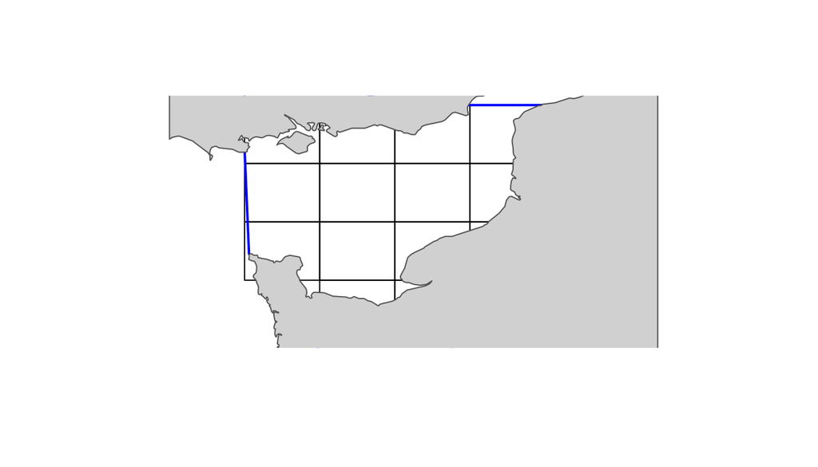

```r
plot(st_geometry(rect)) # tracé rapide des rectangles
plot(st_geometry(div), border = "blue", lwd = 2, add = TRUE)
plot(st_geometry(cote), col = "grey85", border = "grey40", add = TRUE) # terres
```

## 1.4 À vous

Répondez aux questions suivantes par du code **et** par une phrase.

1. Quelle période couvrent les données ? L’année 2026 est-elle complète ?
2. Combien d’espèces et d’engins différents ? Que signifie un code d’engin vide (`""`) ?
3. Le total débarqué est-il le même dans `landings.csv` et `landings_rect.csv` ? Pourquoi ?
4. Quel rectangle des débarquements n’existe pas dans la couche `rect` ?

```r
# votre code ici
range(lan$year)
```

```
[1] 2000 2026
```

```r
length(unique(lan$faocode))
```

```
[1] 201
```

```r
listrectgeo<-unique(rect$offname)
listrectlan<-unique(lan_rect$icesrect)

reponse<-listrectlan %in% listrectgeo
reponse
```

```
 [1] FALSE FALSE  TRUE  TRUE  TRUE  TRUE  TRUE  TRUE  TRUE  TRUE  TRUE  TRUE
[13]  TRUE  TRUE  TRUE  TRUE  TRUE
```

```r
!reponse
```

```
 [1]  TRUE  TRUE FALSE FALSE FALSE FALSE FALSE FALSE FALSE FALSE FALSE FALSE
[13] FALSE FALSE FALSE FALSE FALSE
```

```r
listrectlan
```

```
 [1] ""     "27E8" "27E9" "28E8" "28E9" "28F0" "29E8" "29E9" "29F0" "29F1"
[11] "30E9" "30F0" "30F1" "27F0" "28F1" "30E8" "30F2"
```

```r
listrectlan[1:3]
```

```
[1] ""     "27E8" "27E9"
```

```r
listrectlan[reponse]
```

```
 [1] "27E9" "28E8" "28E9" "28F0" "29E8" "29E9" "29F0" "29F1" "30E9" "30F0"
[11] "30F1" "27F0" "28F1" "30E8" "30F2"
```

```r
listrectlan[!reponse]
```

```
[1] ""     "27E8"
```

```r
listrectlan[listrectlan]
```

```
 [1] NA NA NA NA NA NA NA NA NA NA NA NA NA NA NA NA NA
```

*(commentez ici)*

# 2 Choisir une espèce

Pour choisir, regardons les espèces les plus débarquées, avec leur nom français. On joint les deux tableaux avec `merge()` sur le code FAO.

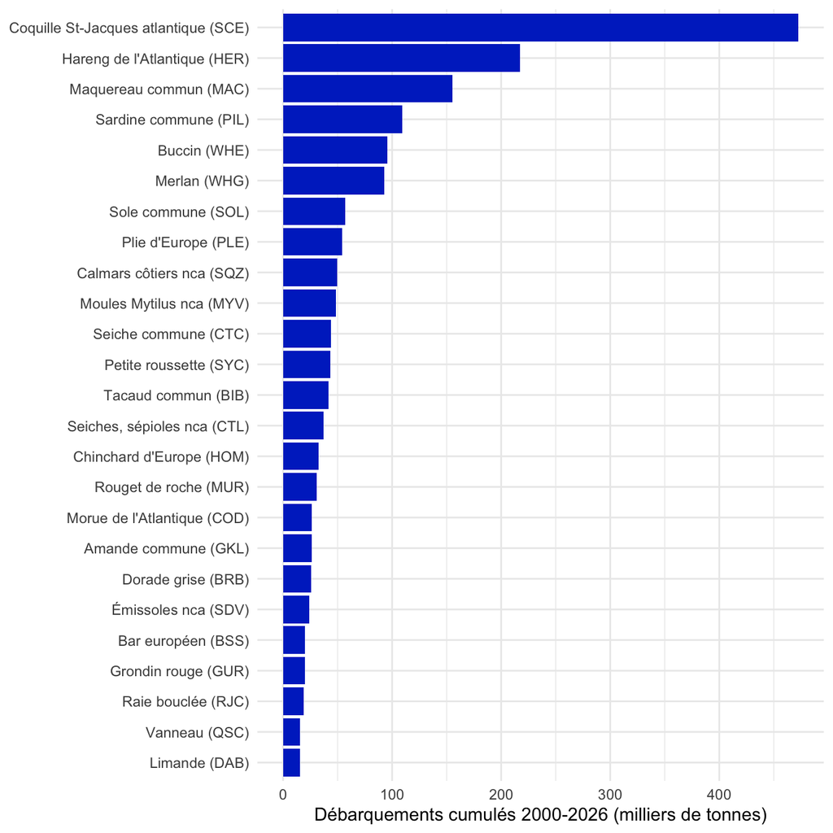

```r
tot_esp <- aggregate(totalweight ~ faocode, data = lan, FUN = sum)
tot_esp <- merge(
    tot_esp,
    ref_espece,
    by.x = "faocode",
    by.y = "ESP_COD_FAO",
    all.x = TRUE
)
tot_esp <- tot_esp[order(tot_esp$totalweight, decreasing = TRUE), ]
top25 <- head(tot_esp, 25)
# étiquette : nom français suivi du code FAO, par exemple « Dorade grise (BRB) »
top25$etiquette <- paste0(top25$ESP_LIB_FAO_FRANCAIS, " (", top25$faocode, ")")
ggplot(top25, aes(x = reorder(etiquette, totalweight), y = totalweight / 1e6)) +
    geom_col(fill = "#0032C8") +
    coord_flip() +
    labs(x = NULL, y = "Débarquements cumulés 2000-2026 (milliers de tonnes)") +
    theme_minimal()
```

## 2.1 À vous

1. Choisissez une espèce : trouvez son code FAO dans `ref_espece` (par exemple avec `ref_espece[grepl("Sole", ref_espece$ESP_LIB_FAO_FRANCAIS), ]`) et stockez-le dans une variable `espece`. Choisissez une autre espèce que la dorade grise, traitée dans l’exemple corrigé.
2. Créez deux tableaux `sp` (à partir de `lan`) et `sp_rect` (à partir de `lan_rect`) ne contenant que cette espèce, **sans l’année 2026**.

Toute la suite utilise `espece` : pour analyser une autre espèce, il suffira de changer cette ligne et de recompiler.

```r
# votre code ici
```

*(commentez ici : pourquoi cette espèce ?)*

**AstuceExemple corrigé : la dorade grise**

```r
ref_espece[grepl("Dorade", ref_espece$ESP_LIB_FAO_FRANCAIS), ]
```

```
      ESP_COD_FAO ESP_LIB_FAO_FRANCAIS
977           SBP          Dorades nca
5623          SBR       Dorade de fond
5902          BRB         Dorade grise
5903          STJ      Dorade australe
5915          GSU               Dorade
5925          SBG        Dorade royale
12511         REV          Dorade rose
```

```r
espece_ex <- "BRB" # dorade grise ou griset (Spondyliosoma cantharus)
sp_ex <- lan[lan$faocode == espece_ex & lan$year < 2026, ]
sp_rect_ex <- lan_rect[lan_rect$faocode == espece_ex & lan_rect$year < 2026, ]
nom_espece_ex <- ref_espece$ESP_LIB_FAO_FRANCAIS[ref_espece$ESP_COD_FAO == espece_ex]
nom_espece_ex
```

```
[1] "Dorade grise"
```

La dorade grise (ou griset) est une espèce importante de la Manche Est, au 19<sup>e</sup> rang des débarquements français dans la zone. Elle est pêchée à la fois par des chaluts de fond et par des chaluts pélagiques, ce qui en fait un bon cas pour comparer les métiers.

# 3 Évolution des débarquements annuels

## 3.1 À vous

1. Calculez le total débarqué par année (en tonnes) avec `aggregate()`.
2. Représentez-le avec ggplot2 (points et lignes).
3. Indiquez dans une phrase l’année du maximum et la valeur des débarquements en 2025, **calculées en ligne** avec `` `r ...` ``.

```r
# votre code ici
```

*(commentez ici)*

**AstuceExemple corrigé : la dorade grise**

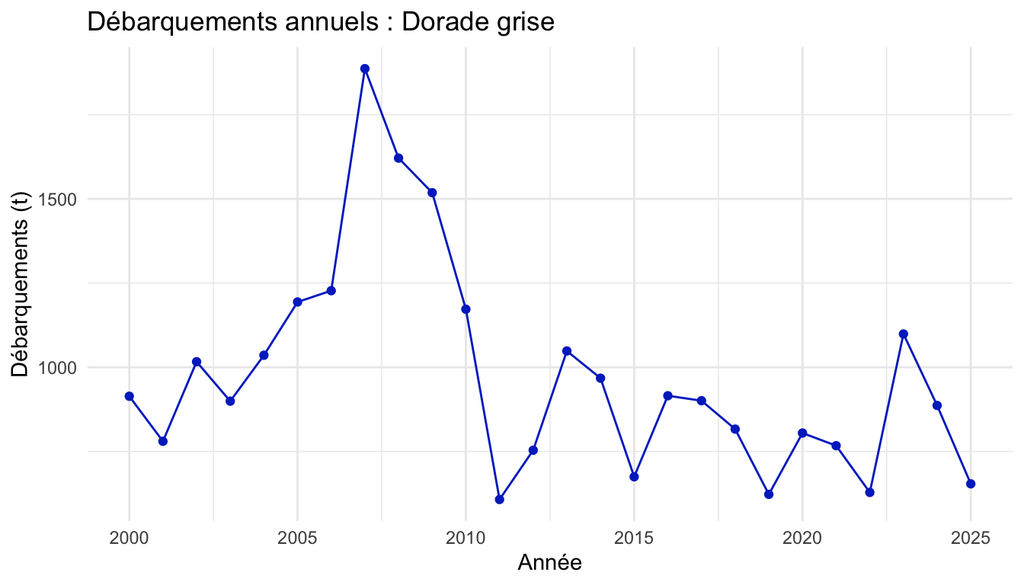

```r
annuel_ex <- aggregate(totalweight ~ year, data = sp_ex, FUN = sum)
annuel_ex$tonnes <- annuel_ex$totalweight / 1000
ggplot(annuel_ex, aes(year, tonnes)) +
    geom_line(colour = "#0032C8") +
    geom_point(colour = "#0032C8") +
    labs(
        x = "Année",
        y = "Débarquements (t)",
        title = paste("Débarquements annuels :", nom_espece_ex)
    ) +
    theme_minimal()
```

```r
annee_max_ex <- annuel_ex$year[which.max(annuel_ex$tonnes)]
t_2025_ex <- round(annuel_ex$tonnes[annuel_ex$year == 2025])
```

Les débarquements de Dorade grise sont maximaux en 2007 et atteignent 654 tonnes en 2025. Ils fluctuent fortement d’une année à l’autre, entre 600 et 1 900 tonnes environ, sans tendance nette sur la période : le pic de 2007 à 2009 est suivi d’un net recul en 2011, puis les débarquements oscillent entre 600 et 1 100 tonnes. Ces chiffres sont des minimums (secret statistique) et ne tiennent pas compte des débarquements des navires étrangers.

# 4 Débarquements par engin

Le code de l’engin est peu parlant : on ajoute son nom avec le référentiel `ref_engin`.

## 4.1 À vous

1. Calculez le total débarqué par engin sur toute la période, ajoutez le nom de l’engin avec `merge()`, et classez les engins par ordre décroissant.
2. Représentez l’évolution annuelle des débarquements des **4 principaux engins** (barres empilées avec `geom_col()`, couleur = engin).

```r
# votre code ici
```

*(commentez ici)*

**AstuceExemple corrigé : la dorade grise**

```r
par_engin_ex <- aggregate(totalweight ~ gear, data = sp_ex, FUN = sum)
par_engin_ex <- merge(
    par_engin_ex,
    ref_engin,
    by.x = "gear",
    by.y = "ENGIN_COD",
    all.x = TRUE
)
par_engin_ex <- par_engin_ex[order(par_engin_ex$totalweight, decreasing = TRUE), ]
par_engin_ex$part <- round(
    100 * par_engin_ex$totalweight / sum(par_engin_ex$totalweight),
    1
)
head(par_engin_ex[, c("gear", "ENGIN_LIB", "part")], 6)
```

```
   gear                     ENGIN_LIB part
10  OTB    Chaluts de fond à panneaux 62.8
15  PTM     Chaluts boeufs pélagiques 26.9
11  OTM Chaluts pélagiques à panneaux  5.2
16  SDN        Sennes de fond danoise  1.2
14  PTB        Chaluts boeufs de fond  0.9
6   GTR                      Trémails  0.7
```

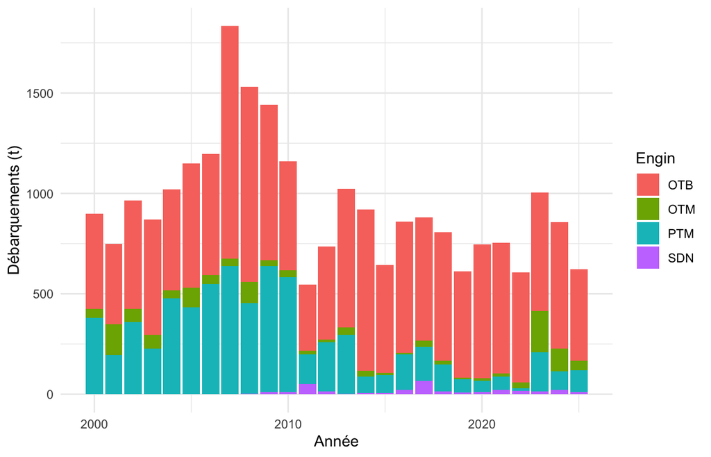

```r
top4_ex <- head(par_engin_ex$gear, 4)
engin_an_ex <- aggregate(
    totalweight ~ year + gear,
    data = sp_ex[sp_ex$gear %in% top4_ex, ],
    FUN = sum
)
ggplot(engin_an_ex, aes(year, totalweight / 1000, fill = gear)) +
    geom_col() +
    labs(x = "Année", y = "Débarquements (t)", fill = "Engin") +
    theme_minimal()
```

# 5 Cartographie annuelle

Pour cartographier, on agrège les débarquements par **année et rectangle**, puis on joint ce tableau à la couche `rect` (objet `sf`) avec `merge()`, en mettant l’objet `sf` en premier pour conserver la géométrie. `geom_sf()` trace ensuite les polygones.

## 5.1 À vous

1. Calculez les débarquements par année et rectangle (en tonnes) à partir de `sp_rect`.
2. Joignez-les à `rect` (`by.x = "offname", by.y = "icesrect"`).
3. Tracez une carte par année (`facet_wrap(~ year)`), en coloriant les rectangles selon les débarquements, avec le contour de la division `div` et le trait de côte `cote` (terres en gris).
4. Quelles zones concentrent les débarquements ? La répartition change-t-elle dans le temps ?

```r
# votre code ici
```

*(commentez ici)*

**AstuceExemple corrigé : la dorade grise**

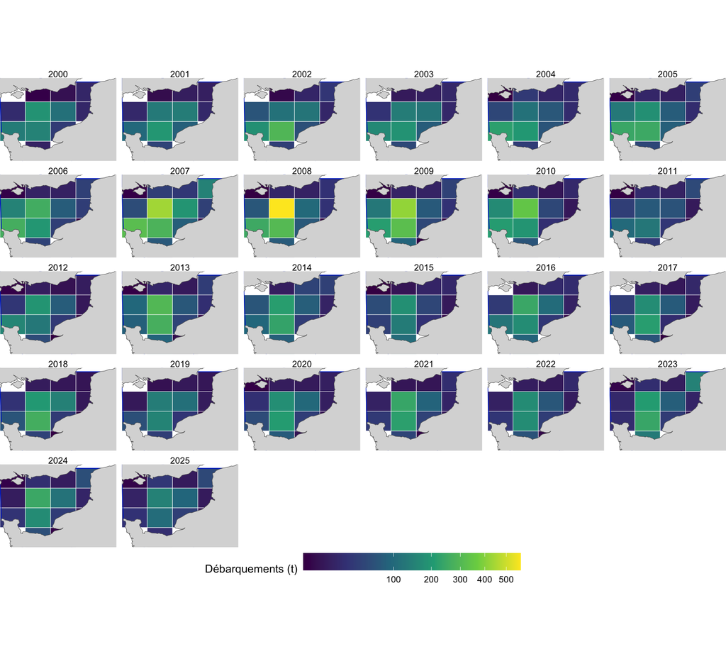

```r
par_rect_ex <- aggregate(totalweight ~ year + icesrect, data = sp_rect_ex, FUN = sum)
par_rect_ex$tonnes <- par_rect_ex$totalweight / 1000
carte_ex <- merge(rect, par_rect_ex, by.x = "offname", by.y = "icesrect")
ggplot() +
    geom_sf(data = carte_ex, aes(fill = tonnes), colour = "white", linewidth = 0.2) +
    geom_sf(data = div, fill = NA, colour = "#0032C8", linewidth = 0.4) +
    geom_sf(data = cote, fill = "grey85", colour = "grey40", linewidth = 0.2) + # terres par-dessus
    scale_fill_viridis_c(name = "Débarquements (t)", trans = "sqrt") +
    coord_sf(xlim = c(-2, 2.6), ylim = c(49, 51.1), expand = FALSE) + # cadrage sur les rectangles
    facet_wrap(~year, ncol = 6) +
    guides(fill = guide_colourbar(barwidth = 15)) +
    theme_void() +
    theme(legend.position = "bottom")
```

# 6 Capture par unité d’effort

La **capture par unité d’effort** (CPUE, de l’anglais *catch per unit effort*) rapporte la capture à l’effort de pêche déployé. Ici, l’effort disponible est le **nombre de marées** (`nbtrip`) : on calcule donc des **kilos débarqués par marée**.

**AvertissementUne CPUE à interpréter avec prudence**

`nbtrip` ne compte que les marées ayant débarqué l’espèce, pas toutes les sorties de la flottille. Une marée de fileyeur côtier et une marée de chalutier hauturier ne sont pas comparables : on calcule donc la CPUE **engin par engin**.

## 6.1 À vous

1. Pour les 3 principaux engins, calculez par année la CPUE : somme des kilos / somme des marées.
2. Représentez son évolution, avec une courbe par engin.
3. Les CPUE évoluent-elles comme les débarquements totaux ? Qu’en concluez-vous sur l’abondance de l’espèce ?

```r
# votre code ici
```

*(commentez ici)*

**AstuceExemple corrigé : la dorade grise**

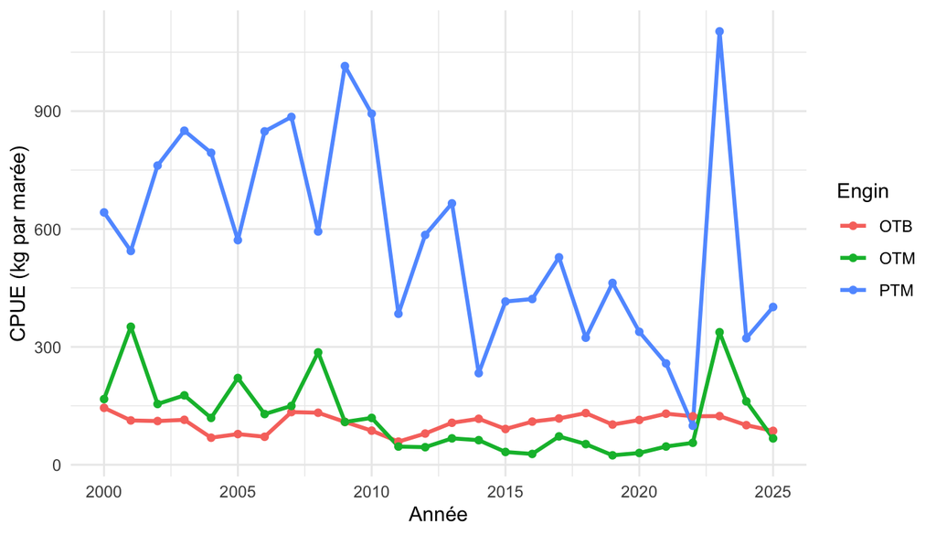

```r
top3_ex <- head(par_engin_ex$gear, 3)
cpue_ex <- aggregate(
    cbind(totalweight, nbtrip) ~ year + gear,
    data = sp_ex[sp_ex$gear %in% top3_ex, ],
    FUN = sum
)
cpue_ex$kg_maree <- cpue_ex$totalweight / cpue_ex$nbtrip
ggplot(cpue_ex, aes(year, kg_maree, colour = gear)) +
    geom_line(linewidth = 1) +
    geom_point() +
    labs(x = "Année", y = "CPUE (kg par marée)", colour = "Engin") +
    theme_minimal()
```

Les niveaux de CPUE diffèrent beaucoup d’un engin à l’autre. Les chaluts bœufs pélagiques (`PTM`) débarquent plusieurs centaines de kilos par marée : ils ciblent les bancs de dorade grise. Pour les chaluts de fond (`OTB`), c’est une capture parmi d’autres, autour de 100 kg par marée. D’où l’intérêt de séparer les engins.

# 7 Synthèse

Rédigez une courte conclusion (5 à 10 lignes) qui résume ce que vous avez appris sur votre espèce : tendance des débarquements, principaux engins, zones de pêche, CPUE. Rappelez les **limites des données** (secret statistique, effort incomplet, année 2026). Compilez ensuite le document et envoyez le `.qmd` et le `.html`.

*(rédigez ici)*